# Chapter 1 - Data Visualization

# 4 - Facets

## 4.1 - Notes

One additional way to show your data is to split your plot into subplots, also called facets. Facets can be created using the facet_wrap() function. There are several arguments you can supply to the facet function, including: 1. ~ = Formula (i.e. ~ class, nrow = 2) 2. grid = Two facets (i.e. drv ~ cyl) 3 . = neither rows nor columns (i.e. . ~ cyl)

## 4.2 - Exercises

**1 - What happens if you facet on a continious variable?**

Lets see.

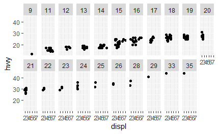

It looks messy!

**2 - What do the empty cells in a plot with facet_grid(drv ~ cyl) mean? How do they relate to this plot?**

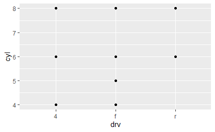

Empty cells simply means that there are some drv and cyl combinations that have no values (hence empty). From the graph above I would guess that drv r with cyl 4 + 5 should be empty. Lets test that.

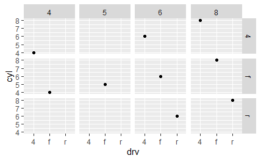

```r
ggplot(data = mpg) +
  geom_point(mapping = aes(x = drv, y = cyl)) +
  facet_grid(drv ~ cyl)
```

This assumption seems to be correct.

**3 - What plots does the following code make? What does . do?**

First plot:

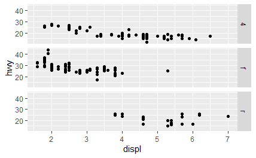

I would guess this would make a facet with one column and alot of rows.

Second plot:

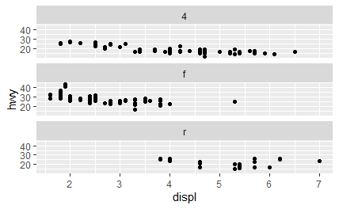

**4 - Take this faceted plot. What are the advantages and disadvantages of using faceting instead of color aesthetic?**

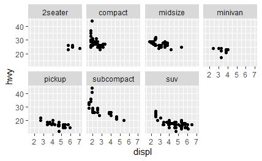

Advantages * You split up your view. Make it simpler if you have a larger dataset. * If you have many variables to show, it can be difficult to see differences in shapes and colour. * If the cases are somehow independent of each other.

Disadvantages * If you just have a small dataset, it can seem empty. * Difficult to compare direct values.

**5 - What does nrow and ncol do in facets? And why does not facet_grid() have a nrow and ncol variable?**

I will need to look at the documentation of facets to figure this out.

Ncol does: number of columns. nrow = number of rows. This is needed at facet wrap only facets on one variable.

These variables are not needed for facet_grid() as this function lays it out in rows and columns dependent on the data set.

**6 - When using facet_grid() you should usually put the variable with more unique levels in the columns, why?**

This is probably because it is easier to read if its longer in the column compared to rows.

# 5 - Geometric Objects

## 5.1 - Notes

You make different plots/graphs in R by using different geoms (geometric object). These can include:

- geom_point = scatter

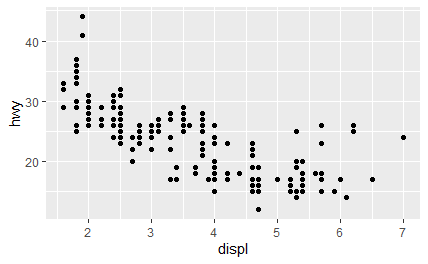

- geom_smooth = line graph

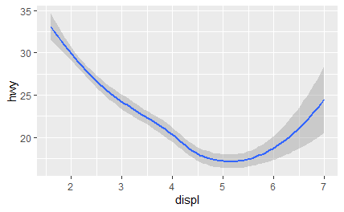

While all geoms takes mapping functions, they cant contain the same type of asthetics. For example a line graph is hard pressed to contain shapes, and different colours deppendent on the class. However, for smooth geoms you could for example set the line type like this:

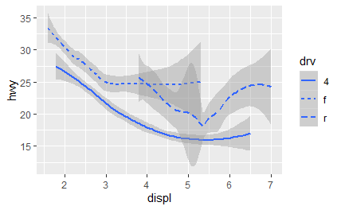

The problem here is however that you esentially write the code two times. An alternative is to write code like this:

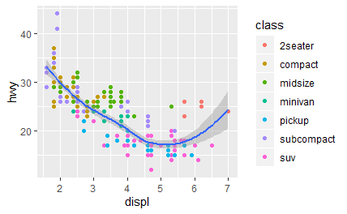

See the cheatsheet for an overview of all types of geoms.

## 5.2 - Exercises

**1 - What geom would you use to draw a line chart, boxplot, hisogram, or area chart?**

**2 - Run this code in your head. And predict outcome**

I predict that the below code with make a coloured line graph (based on drv) with points and without the standard error (SE = false).

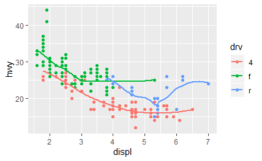

Correct!

**3 - What does show.legend = FALSE do? What happens if you remove it?**

It removes legends box. It still shows titles of rows and columns.

**4 - What does the se arrgument in geom_smooth() do?**

It creates a standard error smoothing.

**6 - Recreate some R code that generates some plots I see in the book**

Plot 1

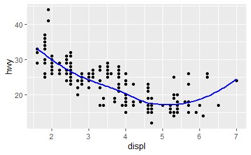

Plot 2:

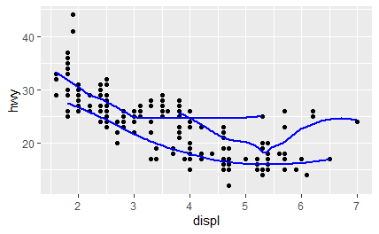

Graph 3:

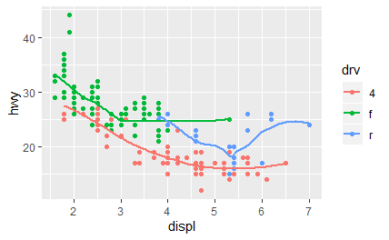

Graph 4:

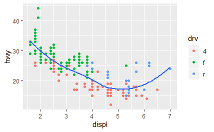

Graph 5:

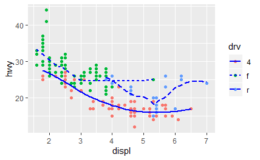

Graph 6:

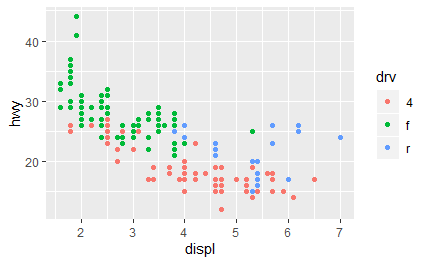

# 6 - Statistical Transformation

## 6.1 - Notes

Some plots automatically calculate new values for your plots. An example is the diaomonds data set where there is no count variable, however, this is calculated when using bar graphs. See this.

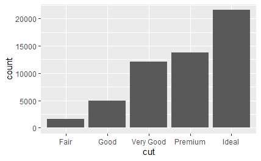

When doing this, the plots bins the data, and counts the number/count that falls within each bin. This occurs for bar charts, histograms, and frequency polygons.

Other automatically calculated stuff can include smoothness model, and summary from boxplots.

The algorithms used for these transformations are called a stat (short for statistical transformation).

You can see/view whch stat geoms uses by looking at the ? fuction.

Here it says "“geom_bar() uses stat_count() by default”".

You can actually use stats interchangibally. The previous graph can also be made like this.

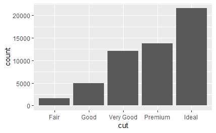

There are three reasons you might choose to use stats over geoms. 1. Overide default stat (i.e. change from count to identity)

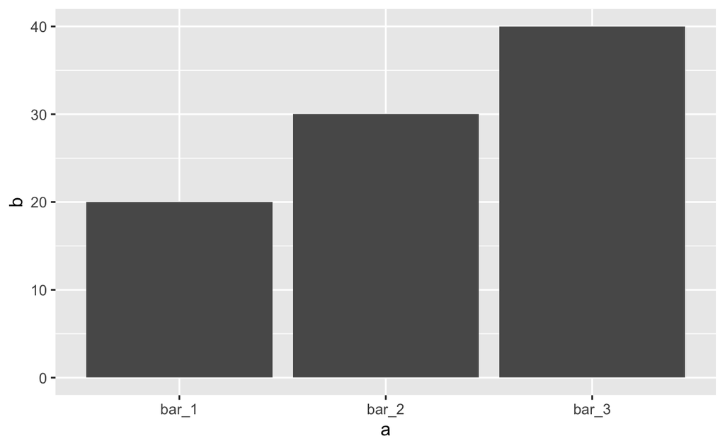

2. Overide defailt mapping. You might want to show something other than a normal Y column, for example proportion.

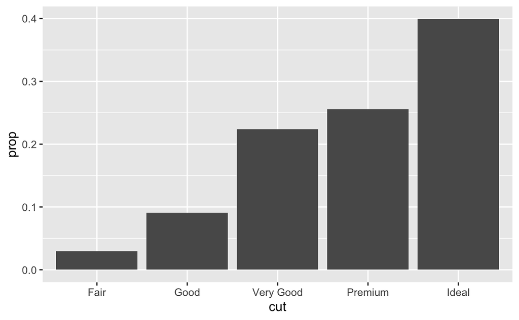

3. You can add more summary data to the plot.

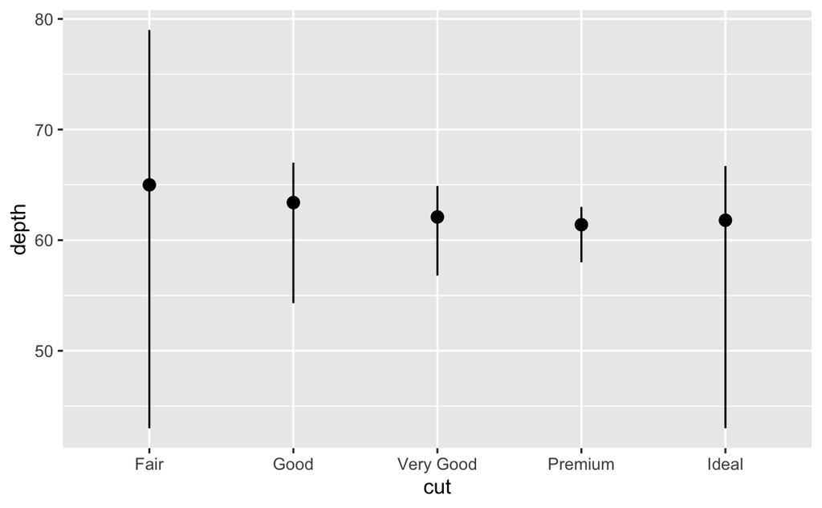

## 6.2 - Excersises

**1 - What is the default geom associated with stat_summary()? How could you rewrite the previous plat using geom instead of stat?**

I will first look at the documentation for stat_summary()

```r
?stat_summary
```

Here it says we can use geom_pointrange. Lets try that.

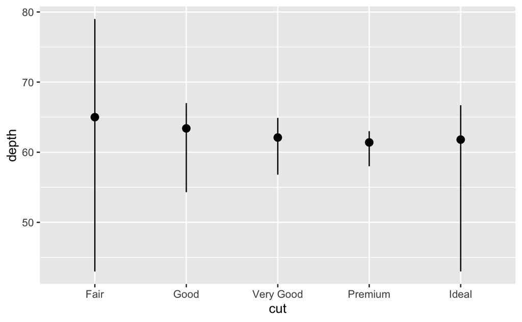

**2 - What does geom_col() do? How is it different to geom_bar()?**

Lets find out.

```r
?geom_col()
```

Geom_bar makes the height of the bar proportional to number of cases in each group. If you want them to be reperesent values in the acctual data, geom_col() does this. I.e. geom_bar() uses stat_count, while geom_col() uses stat_identity.

**3 - Most geoms and stats come in pairs that are almost always used in concert. What does these pairs have in common?**

We should read documentation.

[output not shown]

They often have similar names. They often do the same thing. Also, they use each other for the same thing. I.e. geom uses a stat, and a stat shows it using a geom. Dont really know why there are two types. Maybe to make it easier in edgecases.

**4 - What variables does stat_smooth() compute? What parameter controls its behavior?**

```r
?stat_smooth()
```

Stat smooth compute the SE using the predictdf function (usually). Also, y, ymin, and yma. The parameters that controls its behavior is method, formula, and na.rm.

**5 - What is the problems with these graphs?**

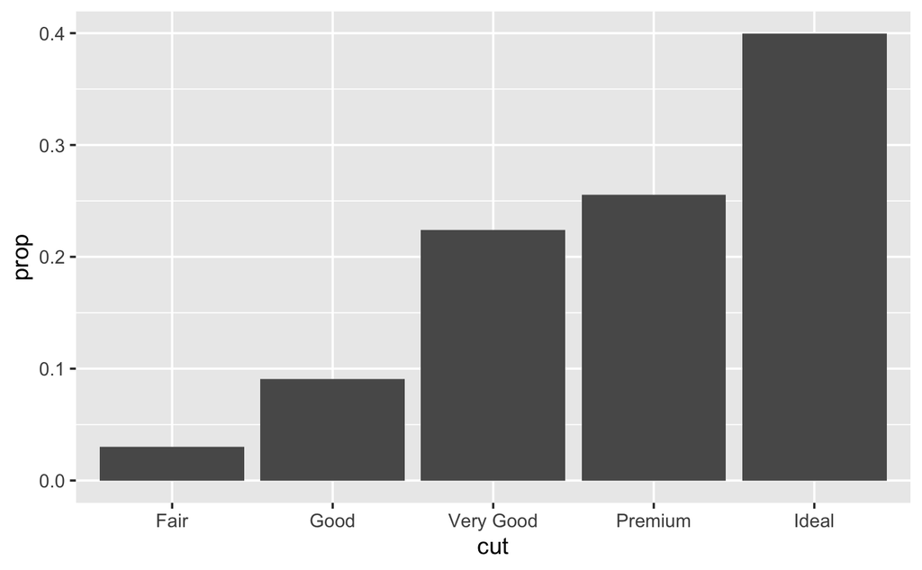

# 7 - Position Adjustments

## 7.1 - Notes

You can fill bar charts using the color aesthetic.

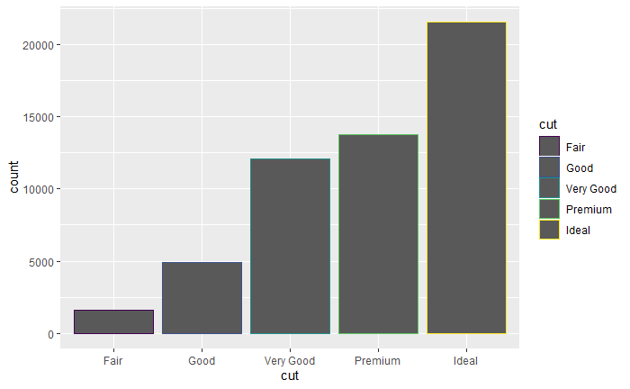

Or better yet

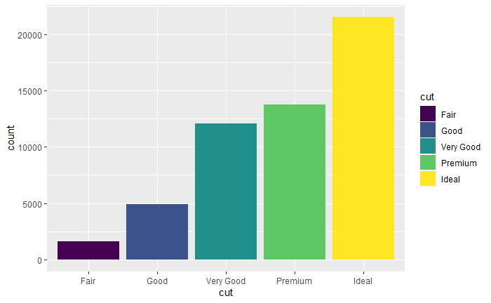

You can also fill stuff in different variables like this:

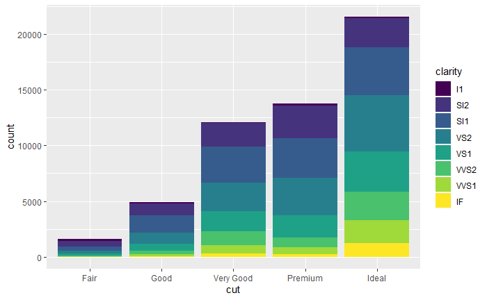

You can use position function to set how the different colors should be positioned. In the below example they are positioned based on their identity.

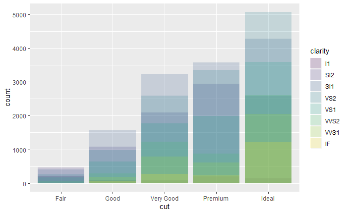

Alpha stand for ocupizaty.

You can also set a fill position

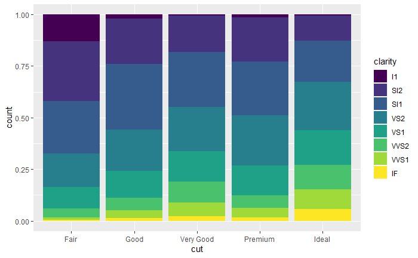

Here we fill the entire Y axis. This makes it easier to compare propoprtions of clarity inside the same sample.

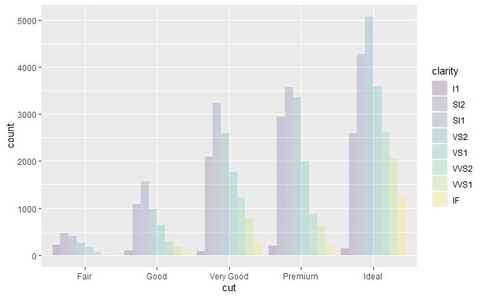

There are also more types of adjustements that are more useful for other types of geoms. For example, if points overlap (called overplotting) you can avoid this by using the jitter function. This function adds some random noise to each variable so that you are able to see them all.

This would in theory make your graph less accurate at small scales, however, more accurate at large scales.

YOu can also use geom_jitter() to do this quickly.

Like this:

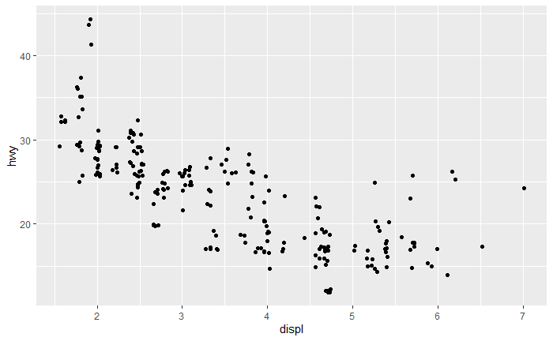